# Bus Stop Finding

2023-11-16

# Finding optimal bus stops

## Creating base layer map

Here we also set the crs to WGS84 as it causes calculation later to be simple as other data is left as lat lon coordinated.

```r
#If we do not want the subzone lines
subzones <- st_read(dsn = "dataset/basemap", layer = "MP14_SUBZONE_NO_SEA_PL")
base_map_no_border <- st_read(dsn = "dataset/basemap", layer = "SGP_adm0")
base_map_no_border <- base_map_no_border %>% select(ISO)
base_map_no_border <- st_transform(base_map_no_border, crs=4326)

#If we want the subzone lines
base_map <- st_read(dsn = "dataset/basemap", layer = "MP14_SUBZONE_NO_SEA_PL")
base_map <- st_transform(base_map, crs=4326)
base_map <- st_make_valid(base_map)
```

## Loading data

In this file, we will be loading 4 main datasets: - Youth density - HDB locations - Bus Stop locations - Nightlife Locations

```r
#Youth density
yth_data <- read.csv("dataset/filteredSG_population_density.csv") %>% select(longitude, latitude, youth)
yth_spatial <- st_as_sf(yth_data, coords = c("longitude", "latitude"), crs = 4326)


#HDB Locations
hdb <- read.csv("dataset/hdb.csv") %>% mutate(addr = paste(blk_no,street)) %>% select(addr,lat,lng)
hdb_spatial <- st_as_sf(hdb, coords = c("lng", "lat"), crs = 4326)


#Read & Load Bus Stop Data
bus_data <- data.frame()
for(i in 0:10) {
  file_name <- paste0("dataset/busstops/response(", i, ").json")
  # Handle the case for response.json (without the index)
  if(i == 0) {
    file_name <- "dataset/busstops/response.json"
  }
  json_read <- fromJSON(file_name, flatten = TRUE)
  bus_data <- rbind(bus_data, json_read$value)
}
bus_spatial <- st_as_sf(bus_data, coords = c("Longitude", "Latitude"), crs = 4326)


#Nightlife DataFrame
nightlife <- st_read('dataset/processed_datasets/nightlife_locations.geojson', crs = st_crs(subzones))
```

```
## Simple feature collection with 283 features and 20 fields
## Geometry type: POINT
## Dimension:     XY
## Bounding box:  xmin: 28406.44 ymin: 28767.68 xmax: 31149.17 ymax: 33145.48
## Projected CRS: SVY21
```

```r
nightlife <- st_transform(nightlife, crs = st_crs(4326))
```

# HDBs Bus Stop Analysis

## Visualizing Youth Density

So the first step is to see how youth density looks like. Now what we notice is that youth density is a point plot, so let’s see how that looks.

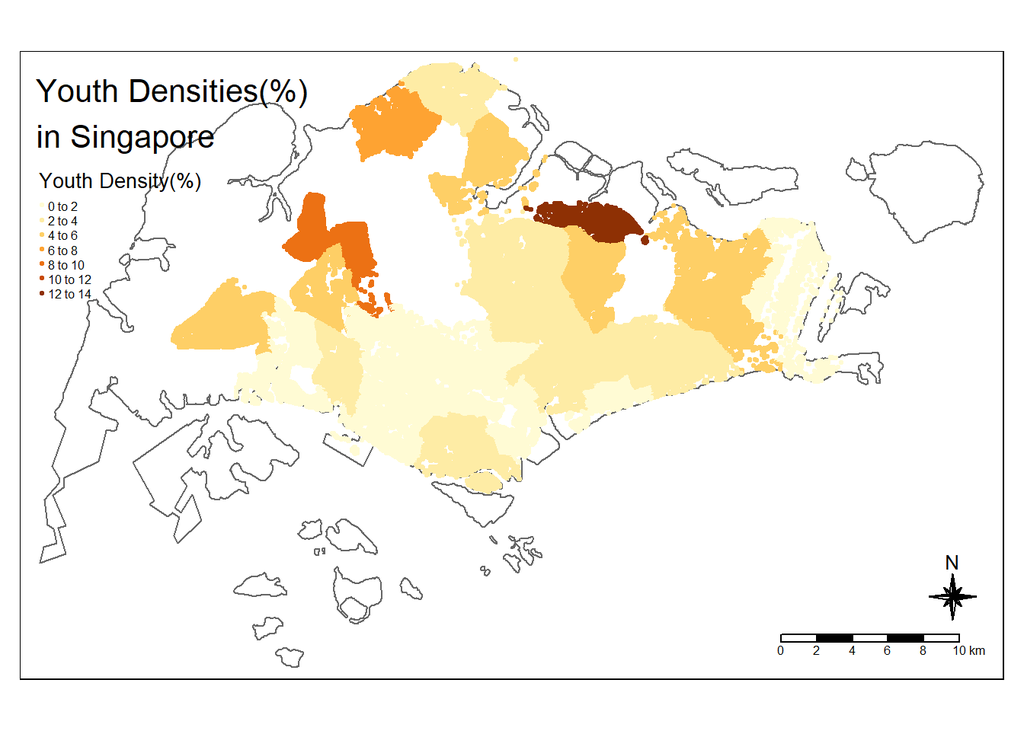

```r
#Plot the points to visualise how the values look #plot takes a while to load
yth_spatial_map <- tm_shape(base_map_no_border) + tm_borders() +
  tm_shape(yth_spatial) + tm_dots(size = 0.05, col = 'youth', title = 'Youth Density(%)')  +
  tm_compass(type="8star", size = 2) +
  tm_scale_bar(width = 0.15) +
  tm_layout(legend.format = list(digits = 0),
            legend.position = c("left", "top"),
            legend.text.size = 0.5,
            legend.title.size = 1,
            title="Youth Densities(%) \nin Singapore",
            title.position = c('left', 'top'))
yth_spatial_map
```

```r
tmap_save(yth_spatial_map, filename = "plots/optimal_stops/yth_spatial_map.png")
```

```
## Map saved to C:\Users\shayer\Documents\NUS\Y3S1\BT4015\happyhour\plots\optimal_stops\yth_spatial_map.png
```

```
## Resolution: 2625.165 by 1679.894 pixels
```

```
## Size: 8.75055 by 5.599648 inches (300 dpi)
```

No what we realise is that the youth points are clustered around a certain value, so we can actually represent them as polygons instead.

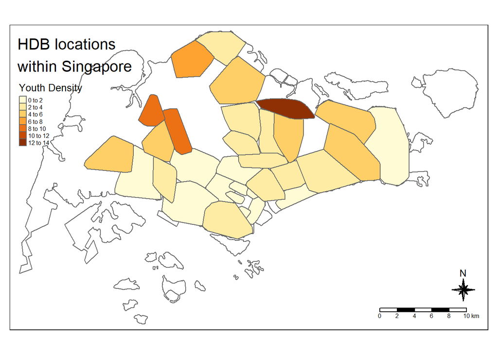

```r
#We notice that a lot of the same values are congregated together, so lets make them into polygon
#Group points with the same value and create convex hulls
grouped_points <- yth_spatial %>%
  group_by(youth) %>%
  summarize()
yth_poly <- grouped_points %>%
  st_convex_hull()
yth_poly <- yth_poly[-14,] #remove the individual point which is out of place

#Lets see how this looks like
yth_poly_plot <- tm_shape(base_map_no_border) + tm_borders() +
  tm_shape(yth_poly) + tm_polygons(col = 'youth', title = 'Youth Density') +
  tm_compass(type="8star", size = 2) +
  tm_scale_bar(width = 0.15) +
  tm_layout(legend.format = list(digits = 0),
            legend.position = c("left", "top"),
            legend.text.size = 0.5,
            legend.title.size = 1,
            title="HDB locations \nwithin Singapore",
            title.position = c('left', 'top'))
yth_poly_plot
```

```r
tmap_save(yth_poly_plot, filename = "plots/optimal_stops/yth_poly_map.png")
```

```
## Map saved to C:\Users\shayer\Documents\NUS\Y3S1\BT4015\happyhour\plots\optimal_stops\yth_poly_map.png
```

```
## Resolution: 2625.165 by 1679.894 pixels
```

```
## Size: 8.75055 by 5.599648 inches (300 dpi)
```

Computation is MUCH faster now as we have reduced from 217054 data points to 32 polygons, great!  
Now lets visualise the HDBs.

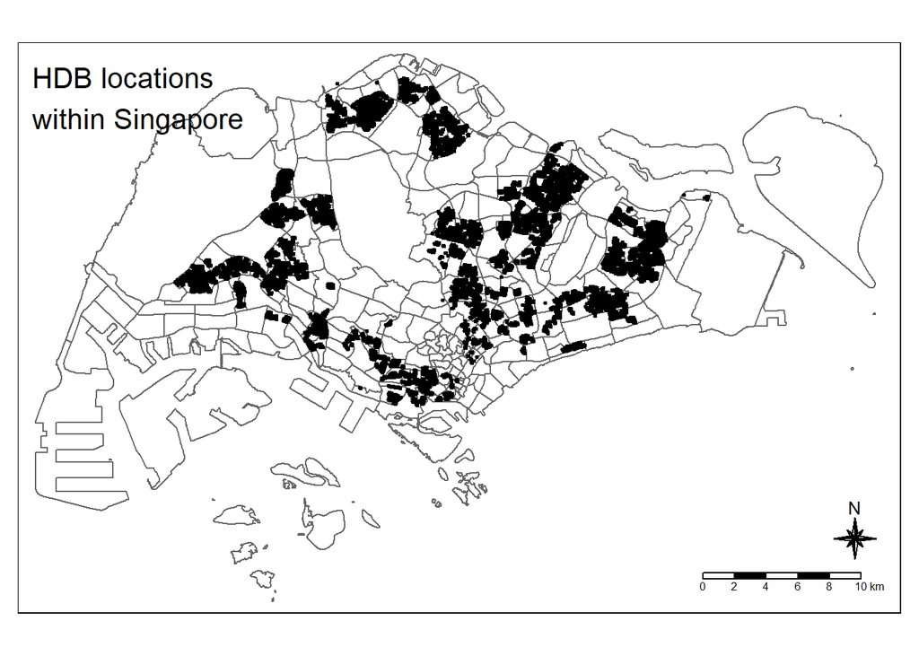

```r
joined <- st_join(hdb_spatial,yth_poly) #combine the HDB data with the youth density to assign youth density values to each HDB

#HDB point graph
hdb_point_plot <- tm_shape(base_map) + tm_borders() +
  tm_shape(hdb_spatial) + tm_dots(size = 0.1, scale = 0.5, col = 'black')  +
  tm_compass(type="8star", size = 2) +
  tm_scale_bar(width = 0.15) +
  tm_layout(legend.format = list(digits = 0),
            legend.position = c("left", "bottom"),
            legend.text.size = 0.75,
            legend.title.size = 1.5,
            title="HDB locations \nwithin Singapore",
            title.position = c('left', 'top'))

hdb_point_plot
```

```r
tmap_save(hdb_point_plot, filename = "plots/optimal_stops/hdb_point_plot.png")
```

```
## Map saved to C:\Users\shayer\Documents\NUS\Y3S1\BT4015\happyhour\plots\optimal_stops\hdb_point_plot.png
```

```
## Resolution: 2611.606 by 1688.616 pixels
```

```
## Size: 8.705352 by 5.628721 inches (300 dpi)
```

Lastly, lets see the combination of both youth density and HDBs

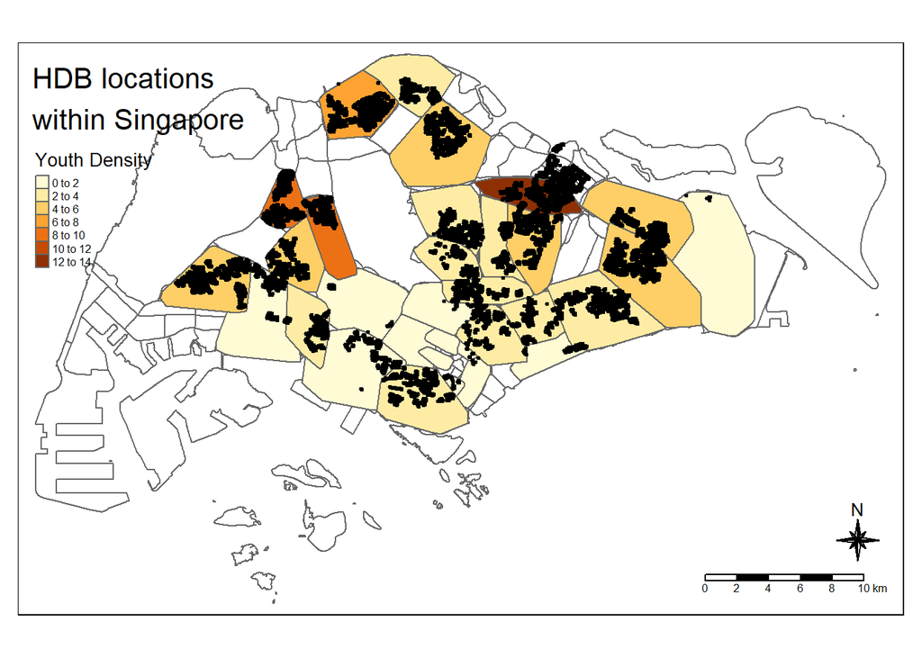

```r
hdb_yth_plot <- tm_shape(base_map) + tm_borders() +
  tm_shape(yth_poly) + tm_polygons(col = 'youth', title = 'Youth Density') +
    tm_shape(hdb_spatial) + tm_dots(size = 0.1, scale = 0.5, col = 'black')  +
  tm_compass(type="8star", size = 2) +
  tm_scale_bar(width = 0.15) +
  tm_layout(legend.format = list(digits = 0),
            legend.position = c("left", "top"),
            legend.text.size = 0.5,
            legend.title.size = 1,
            title="HDB locations \nwithin Singapore",
            title.position = c('left', 'top'))

hdb_yth_plot
```

```r
tmap_save(hdb_yth_plot, filename = "plots/optimal_stops/hdb_yth_plot.png")
```

```
## Map saved to C:\Users\shayer\Documents\NUS\Y3S1\BT4015\happyhour\plots\optimal_stops\hdb_yth_plot.png
```

```
## Resolution: 2611.606 by 1688.616 pixels
```

```
## Size: 8.705352 by 5.628721 inches (300 dpi)
```

## Fixing data

So now our objective is to assing a youth density value to each HDB. However, what we noticed is that some HDBs (especially in the punggol area) are missing values and we also have some locations with multiple values. Now in order to fill in the data, rather than imputing with the mean, we decided that we can interpolate the data.

In terms of deciding which interpolation method to use, we decided to use IDW as the appropriate method to fill in the data. This is becaus we wanted a deterministic model in order to fill in the missing data **consistently**. Furthermore, kringing would not perform well for this form of missing data which only has data from one side but not the other.

So our first step is to create a simple dataframe which contains both the youth density data and HDB locations.

```r
joined <- st_join(hdb_spatial,yth_poly) #combine the HDB data with the youth density to assign youth density values to each HDB

#First, we need to seperate out data with NA values and only interpolate on coordinates with points

joined_noNA <- joined %>% filter(!is.na(youth))
joined_spatial <- as(joined_noNA, "Spatial")
```

We then create our raster grid for the IDW process.

```r
base_spatial <- as(base_map, 'Spatial')

#Creating a raster layer for interpolation
grd              <- as.data.frame(spsample(base_spatial, "regular", n=10000))
names(grd)       <- c("lat", "lng")
coordinates(grd) <- c("lat", "lng")
gridded(grd)     <- TRUE
fullgrid(grd)    <- TRUE

crs(grd) <- crs(base_spatial)
```

Now onto creating the IDW, determining a good idp value and plotting it out.

```r
yth.idw <- gstat::idw(youth ~ 1, joined_spatial, newdata=grd, idp=3.0) #idp of 3 chosen as we want closer values to mean more
```

```
## [inverse distance weighted interpolation]
```

```r
#Find out what is a good idp value to use #10min runtime
IDW.out <- vector(length = length(joined_spatial))
for (i in 1:length(joined_spatial)) {
  IDW.out[i] <- gstat::idw(youth ~ 1, joined_spatial[-i,], joined_spatial[i,], idp=3.0)$var1.pred
}
```

[output not shown]

[output cut: 12586 more lines]

[output not shown]

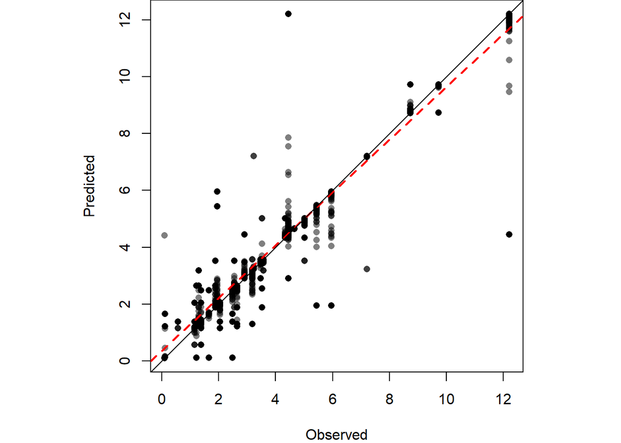

```r
#Plot the differences
OP <- par(pty="s", mar=c(4,3,0,0))
plot(IDW.out ~ joined_spatial$youth, asp=1, xlab="Observed", ylab="Predicted", pch=16,
     col=rgb(0,0,0,0.5))
abline(lm(IDW.out ~ joined_spatial$youth), col="red", lw=2,lty=2)
abline(0,1)
```

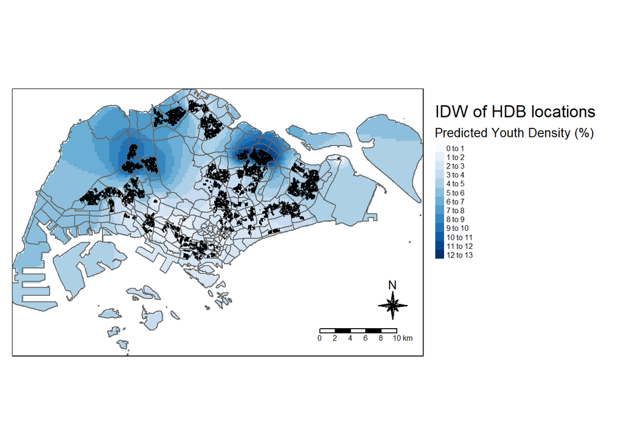

```r
par(OP)

#Looks like the IDW looks valid

r_hdb_idw       <- raster(yth.idw)
r_hdb_idw.m     <- mask(r_hdb_idw, base_spatial)


idw_full <- tm_shape(r_hdb_idw.m) +
  tm_raster(n=10,palette = "Blues", stretch.palette = FALSE,title="Predicted Youth Density (%)") +
  tm_shape(base_map) + tm_borders() + tm_fill(alpha = 0) +
  tm_shape(joined_spatial) + tm_dots(size=0.005) +
  tm_legend(legend.outside=TRUE) +
  tm_compass(type="8star", size = 2) +
  tm_scale_bar(width = 0.15) +
  tm_layout(legend.format = list(digits = 0),
            legend.position = c("left", "top"),
            legend.text.size = 0.5,
            legend.title.size = 1,
            title="IDW of HDB locations",
            title.position = c('left', 'top'))

idw_full
```

```r
tmap_save(idw_full, filename = "plots/optimal_stops/idw_full.png")
```

```
## Map saved to C:\Users\shayer\Documents\NUS\Y3S1\BT4015\happyhour\plots\optimal_stops\idw_full.png
```

```
## Resolution: 2605.961 by 1692.274 pixels
```

```
## Size: 8.686538 by 5.640912 inches (300 dpi)
```

## Filtering

Now that we have assigned each HDB a youth density value, the next step would be to filter out HDBs with lower youth density values.

The first step to doing that is by visualising the IDW values in a histogram. We hace also calculated some key stats for the youth density values.

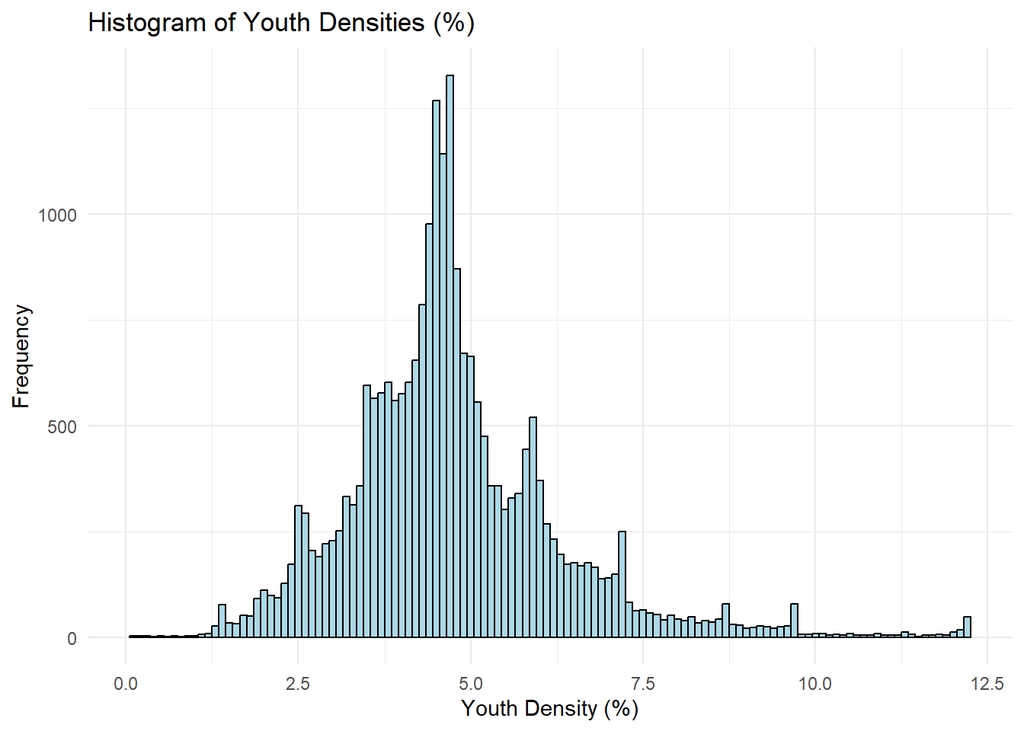

```r
#EDA on youth density, making a histogram of youth densities
yth_hist <- r_hdb_idw@data@values

hist <- ggplot(data.frame(values = yth_hist), aes(x = values)) +
  geom_histogram(binwidth = 0.1, fill = "lightblue", color = "black", aes(y = ..count..)) +
  ggtitle("Histogram of Youth Densities (%)") +
  xlab("Youth Density (%)") +
  ylab("Frequency") + theme_minimal()

hist
```

```r
ggsave("plots/optimal_stops/hist.png",hist)
#A couple of statistics for youth density
mean(yth_hist)
```

```
## [1] 4.742153
```

```r
median(yth_hist)
```

```
## [1] 4.581621
```

```r
quantile(yth_hist,0.25)
```

```
##     25%
## 3.82874
```

```r
quantile(yth_hist,0.75)
```

```
##      75%
## 5.423696
```

```r
max(yth_hist)
```

```
## [1] 12.2176
```

The next step would be to determine a good threshold for youth density to filter out the HDB locations. Ideally, we would want to split the HDBs into 2 regions for the ideal bus stops to run well.

Over a number of iterations, we set this filter to take the HDBs in the top 50% of youth densitys.

Unfortunately, because assigning each HDB to the value from the raster grid is computationally intensive, we decided to reclassify the raster layer into 25 layers from 0 to 12.5 with a 0.5 interval. This can be seen in the chunk below.

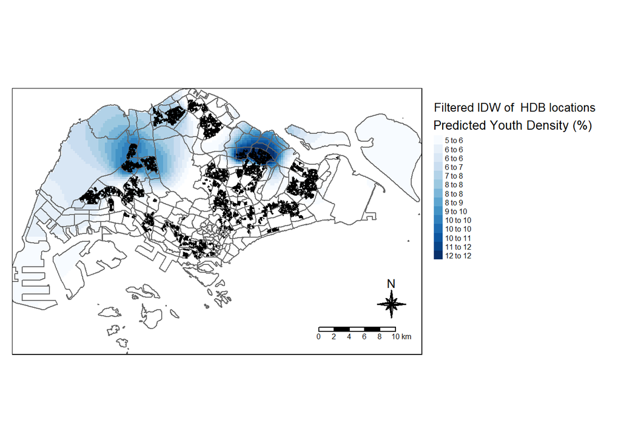

```r
#Before we move on, we realise that with spatial interpolation, the assigning of values will take a really long time
#As such, we reclassify the values into groups before converting them nto polygons for analysis

reclass_value_idw <- c(0,0.25,0) #to reclass values into 25 different bins
for (i in seq(0,24,1)) {
  reclass_value_idw[3*i + 4] = 0.25 + 0.5*i
  reclass_value_idw[3*i + 5] = 0.75 + 0.5*i
  reclass_value_idw[3*i + 6] = 0.5 + 0.5*i
}

reclass_r_hdb_idw <- reclassify(as(r_hdb_idw, "RasterLayer"), reclass_value_idw) #reclassify kde values to groups
filtered_r_hdb_idw <- reclass_r_hdb_idw
filtered_r_hdb_idw[filtered_r_hdb_idw <= quantile(yth_hist,0.5)] <- NA

#overlaid IDW polygon plot with hdb plot
filtered_r_hdb_idw.m     <- mask(filtered_r_hdb_idw, base_spatial)


idw_filter <- tm_shape(filtered_r_hdb_idw.m) +
  tm_raster(n=10,palette = "Blues", stretch.palette = FALSE,title="Predicted Youth Density (%)") +
  tm_shape(base_map) + tm_borders() + tm_fill(alpha = 0) +
  tm_shape(joined_spatial) + tm_dots(size=0.005) +
  tm_legend(legend.outside=TRUE) +
  tm_compass(type="8star", size = 2) +
  tm_scale_bar(width = 0.15) +
  tm_layout(legend.format = list(digits = 0),
            legend.position = c("left", "top"),
            legend.text.size = 0.5,
            legend.title.size = 1,
            title="Filtered IDW of  HDB locations",
            title.position = c('left', 'top'))

idw_filter
```

```r
tmap_save(idw_filter, filename = "plots/optimal_stops/idw_filter.png")
```

```
## Map saved to C:\Users\shayer\Documents\NUS\Y3S1\BT4015\happyhour\plots\optimal_stops\idw_filter.png
```

```
## Resolution: 2605.961 by 1692.274 pixels
```

```
## Size: 8.686538 by 5.640912 inches (300 dpi)
```

Now what we are left is to remove the HDBs which lie outside the new raster layer. In order to accomplish this, we convert the raster values into polygons of equal value. Then an intersection is taken to fitler out the remaining HDBs. The resultant plot is as such.

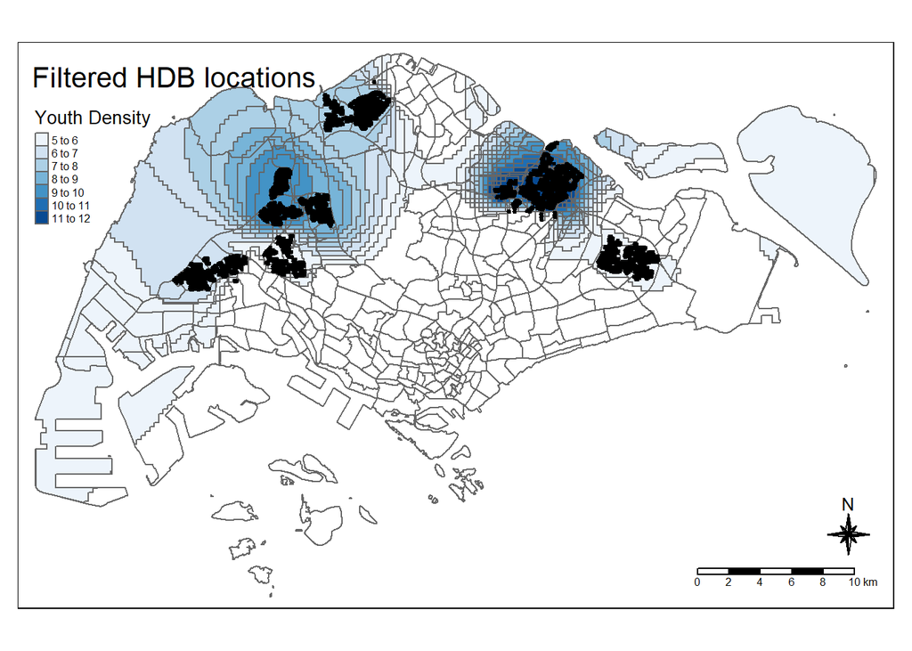

```r
#Converting raster layer into polygons to view overlay over Singapore
threshold <- quantile(yth_hist,0.5) #define a threshold to determine what values of youth density we drop
hdb_idw <- rasterToPolygons(reclass_r_hdb_idw, fun = function(x) {x > threshold},dissolve = TRUE) #
hdb_idw <- st_as_sf(hdb_idw)
hdb_idw <- hdb_idw %>% rename(youth = var1.pred)
hdb_idw <- st_cast(hdb_idw,'MULTIPOLYGON')
st_crs(hdb_idw) <- st_crs("EPSG:4326") #set crs for new polygons
hdb_idw <- st_intersection(hdb_idw, base_map) #to ensure new polygons stay within SG boundary
#assigning each hdb a youth value by intersecting the multipolygons to with all hdbs
hdb_yth_pts <- st_intersection(hdb_spatial, hdb_idw)  #takes some time
idw_final <- tm_shape(base_map) + tm_borders() +
  tm_shape(hdb_idw) + tm_polygons(col = 'youth', title = 'Youth Density', palette = 'Blues') +
    tm_shape(hdb_yth_pts) + tm_dots(size = 0.1, scale = 0.5, col = 'black')  +
  tm_compass(type="8star", size = 2) +
  tm_scale_bar(width = 0.15) +
  tm_layout(legend.format = list(digits = 0),
            legend.position = c("left", "top"),
            legend.text.size = 0.5,
            legend.title.size = 1,
            title="Filtered HDB locations",
            title.position = c('left', 'top'))

idw_final
```

```r
tmap_save(idw_final, filename = "plots/optimal_stops/idw_final.png")
```

```
## Map saved to C:\Users\shayer\Documents\NUS\Y3S1\BT4015\happyhour\plots\optimal_stops\idw_final.png
```

```
## Resolution: 2611.606 by 1688.616 pixels
```

```
## Size: 8.705352 by 5.628721 inches (300 dpi)
```

## Determining HDB Centroids

Now we have the fitered HDBs, we want to find out the centroids of the filtered HDB areas. This is so that we can then find out busstops which are most relevant to these HDBs. In order to accomplish this, we ran a KDE with a bandwidth of 1.4km on the filtered HDBs to view their clustering.

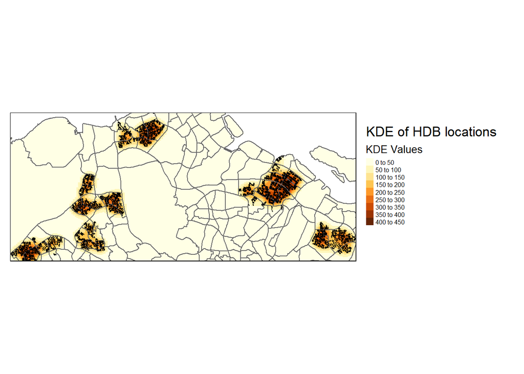

```r
hdb_points <- as(hdb_yth_pts, "Spatial")
hdb_centers <- kde.points(hdb_points, h = 0.013) #1.4km bandwidth
hdb_centers_sf <- st_as_sf(hdb_centers)

r_hdb_centers       <- raster(hdb_centers)
r_hdb_centers.m     <- mask(r_hdb_centers, base_spatial)

kde_first <- tm_shape(r_hdb_centers.m) +
  tm_raster(n=10, stretch.palette = FALSE,title="KDE Values") +
  tm_shape(base_map) + tm_borders() + tm_fill(alpha = 0) +
  tm_shape(hdb_yth_pts) + tm_dots(size=0.005) +
  tm_legend(legend.outside=TRUE) +
  tm_layout(legend.format = list(digits = 0),
            legend.position = c("left", "top"),
            legend.text.size = 0.5,
            legend.title.size = 1,
            title="KDE of HDB locations",
            title.position = c('left', 'top'))

kde_first
```

```r
tmap_save(kde_first, filename = "plots/optimal_stops/kde_first.png")
```

```
## Map saved to C:\Users\shayer\Documents\NUS\Y3S1\BT4015\happyhour\plots\optimal_stops\kde_first.png
```

```
## Resolution: 3202.548 by 1377.028 pixels
```

```
## Size: 10.67516 by 4.590095 inches (300 dpi)
```

We then reclassified the kde values into 5 equal groups from 0 to 500 and removed the first 2 layers. This results in the following.

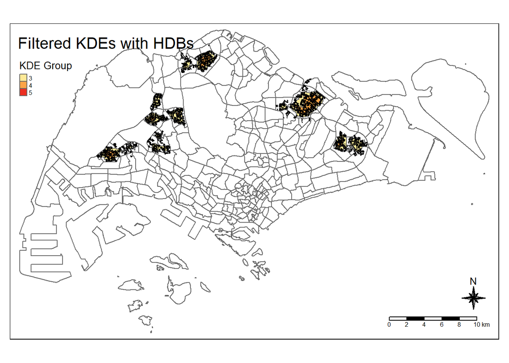

```r
#Reclassify values in raster to make contour lines as seen in KDE plot.
reclass_values <- c(0,100,1, #reclassify kde values from 0-50 in group 1 and so on
                    100,200,2,
                    200,300,3,
                    300,400,4,
                    400,500,5)


reclass_hdb_centers <- reclassify(as(hdb_centers, "RasterLayer"), reclass_values) #reclassify kde values to groups
hdb_centers_poly <- rasterToPolygons(reclass_hdb_centers, dissolve = T, n = 16, digits = 3) #to make a polygon layer
hdb_centers_poly <- st_as_sf(hdb_centers_poly) #to make an SF object
hdb_centers_poly <- hdb_centers_poly[-c(1,2),] #remove polys with low kde values
hdb_centers_poly <- st_cast(hdb_centers_poly,'POLYGON') #to split multipolygon to polygon to obtain centers
hdb_centers_poly$kde <- factor(hdb_centers_poly$kde) #to tell R to recognise the colours as categories

kde_second <- tm_shape(base_map) + tm_borders() +
  tm_shape(hdb_centers_poly) + tm_polygons(col = 'kde', title = 'KDE Group', palette = 'YlOrRd') +
    tm_shape(hdb_yth_pts) + tm_dots(size = 0.01, scale = 0.5, col = 'black')  +
  tm_compass(type="8star", size = 2) +
  tm_scale_bar(width = 0.15) +
  tm_layout(legend.format = list(digits = 0),
            legend.position = c("left", "top"),
            legend.text.size = 0.5,
            legend.title.size = 1,
            title="Filtered KDEs with HDBs",
            title.position = c('left', 'top'))

kde_second
```

```r
tmap_save(kde_second, filename = "plots/optimal_stops/kde_second.png")
```

```
## Map saved to C:\Users\shayer\Documents\NUS\Y3S1\BT4015\happyhour\plots\optimal_stops\kde_second.png
```

```
## Resolution: 2611.606 by 1688.616 pixels
```

```
## Size: 8.705352 by 5.628721 inches (300 dpi)
```

Now it is hard to see the KDE polygons on that plot. To make the polygons easier to view, we plot the centroids of the individual layers to determine the central point of the HDB locations.

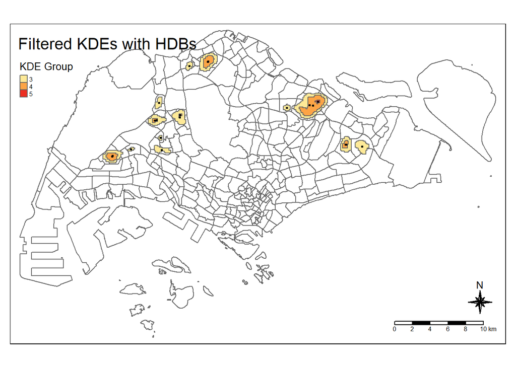

```r
#get the centroids of each polygon
hdb_centers_points <- st_centroid(hdb_centers_poly)
#HDB Centroids
kde_centroid <- tm_shape(base_map) + tm_borders() +
  tm_shape(hdb_centers_poly) + tm_polygons(col = 'kde', title = 'KDE Group', palette = 'YlOrRd') +
    tm_shape(hdb_centers_points) + tm_dots(size = 0.1, scale = 0.5, col = 'black')  +
  tm_compass(type="8star", size = 2) +
  tm_scale_bar(width = 0.15) +
  tm_layout(legend.format = list(digits = 0),
            legend.position = c("left", "top"),
            legend.text.size = 0.5,
            legend.title.size = 1,
            title="Filtered KDEs with HDBs",
            title.position = c('left', 'top'))

kde_centroid
```

```r
tmap_save(kde_centroid, filename = "plots/optimal_stops/kde_centroid.png")
```

```
## Map saved to C:\Users\shayer\Documents\NUS\Y3S1\BT4015\happyhour\plots\optimal_stops\kde_centroid.png
```

```
## Resolution: 2611.606 by 1688.616 pixels
```

```
## Size: 8.705352 by 5.628721 inches (300 dpi)
```

## Bus Stop Mapping

The next set is to find out how the Bus Stops fare with our HDBs. First lets take a look at how the bus stops are distributed around Singapore.

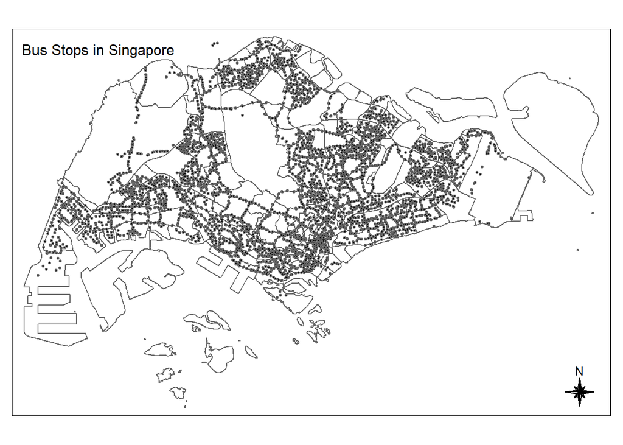

```r
bus_all <- tm_shape(base_map) + tm_borders() +
  tm_shape(bus_spatial) + tm_bubbles(size = 0.15, scale = 0.5, col = 'black')  +
  tm_compass(type="8star", size = 2) +
  tm_layout(legend.format = list(digits = 0),
            legend.position = c("left", "top"),
            legend.text.size = 0.5,
            legend.title.size = 1,
            title="Bus Stops in Singapore",
            title.size = 1,
            title.position = c('left', 'top'))

bus_all
```

```r
tmap_save(bus_all, filename = "plots/optimal_stops/bus_all.png")
```

```
## Map saved to C:\Users\shayer\Documents\NUS\Y3S1\BT4015\happyhour\plots\optimal_stops\bus_all.png
```

```
## Resolution: 2611.606 by 1688.616 pixels
```

```
## Size: 8.705352 by 5.628721 inches (300 dpi)
```

We overlay these with our KDEs earlier.

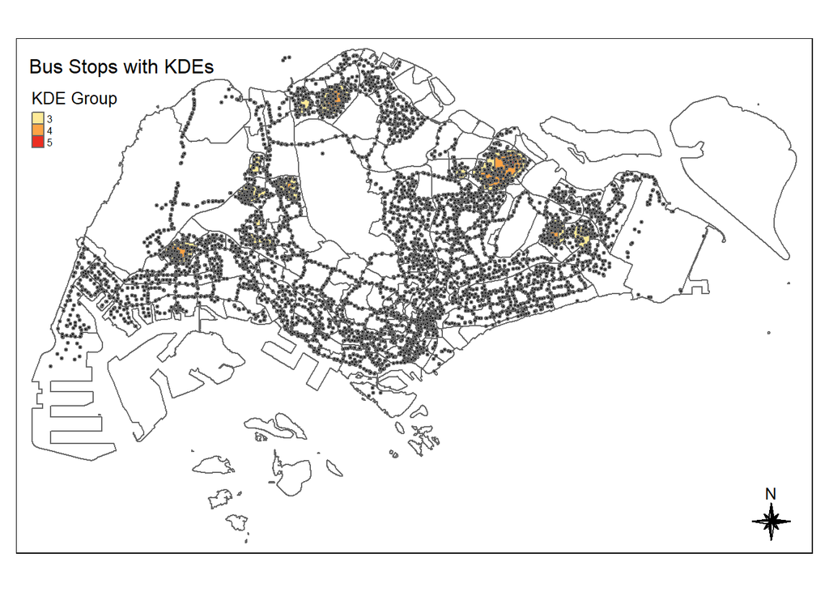

```r
#Map to show how bustops fare with kdes
bus_all_kde <- tm_shape(base_map) + tm_borders() +
  tm_shape(hdb_centers_poly) + tm_polygons(col = 'kde', title = 'KDE Group', palette = 'YlOrRd') +
  tm_shape(bus_spatial) + tm_bubbles(size = 0.15, scale = 0.5, col = 'black')  +
  tm_compass(type="8star", size = 2) +
  tm_layout(legend.format = list(digits = 0),
            legend.position = c("left", "top"),
            legend.text.size = 0.5,
            legend.title.size = 1,
            title="Bus Stops with KDEs",
            title.size = 1,
            title.position = c('left', 'top'))

bus_all_kde
```

```r
tmap_save(bus_all_kde, filename = "plots/optimal_stops/bus_all_kde.png")
```

```
## Map saved to C:\Users\shayer\Documents\NUS\Y3S1\BT4015\happyhour\plots\optimal_stops\bus_all_kde.png
```

```
## Resolution: 2611.606 by 1688.616 pixels
```

```
## Size: 8.705352 by 5.628721 inches (300 dpi)
```

Next filter out only bus stops within these kdes. This step is not really necessary, but is doen to reduce computational intensity when calculating the best bus stop for each.

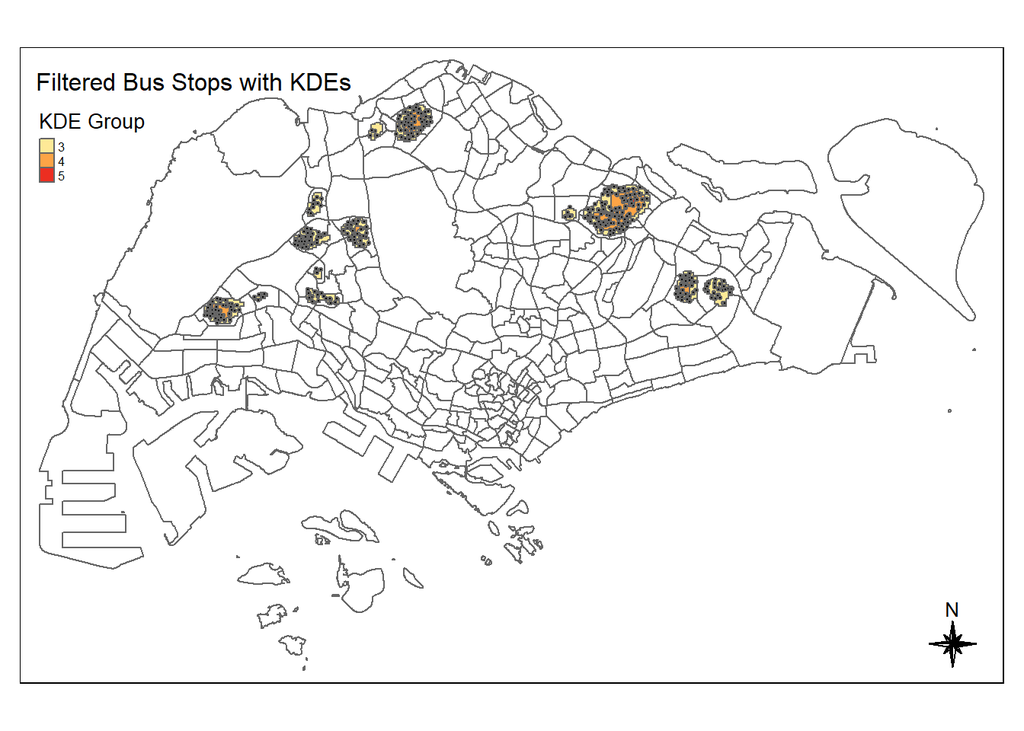

```r
#remove busstops which are not inside the polygons
bus_inside_spatial <- st_intersection(bus_spatial, hdb_centers_poly)
#Show busstops which are inside the KDEs
bus_filtered_kde <- tm_shape(base_map) + tm_borders() +
  tm_shape(hdb_centers_poly) + tm_polygons(col = 'kde', title = 'KDE Group', palette = 'YlOrRd') +
  tm_shape(bus_inside_spatial) + tm_bubbles(size = 0.15, scale = 0.5, col = 'black')  +
  tm_compass(type="8star", size = 2) +
  tm_layout(legend.format = list(digits = 0),
            legend.position = c("left", "top"),
            legend.text.size = 0.5,
            legend.title.size = 1,
            title="Filtered Bus Stops with KDEs",
            title.size = 1,
            title.position = c('left', 'top'))

bus_filtered_kde
```

```r
tmap_save(bus_filtered_kde, filename = "plots/optimal_stops/bus_filtered_kde.png")
```

```
## Map saved to C:\Users\shayer\Documents\NUS\Y3S1\BT4015\happyhour\plots\optimal_stops\bus_filtered_kde.png
```

```
## Resolution: 2611.606 by 1688.616 pixels
```

```
## Size: 8.705352 by 5.628721 inches (300 dpi)
```

Lastly, we find the closest bus stop to each centroid found earlier and assign each polygon a bus stop!

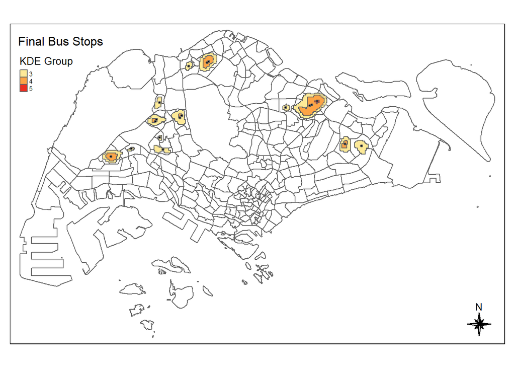

```r
#find closest busstop to each centroid
closest_busstops_index <- st_nearest_feature(hdb_centers_points, bus_inside_spatial)
closest_busstops <- bus_inside_spatial[closest_busstops_index,]

#busstops

bus_final <- tm_shape(base_map) + tm_borders() +
  tm_shape(hdb_centers_poly) + tm_polygons(col = 'kde', title = 'KDE Group', palette = 'YlOrRd') +
  tm_shape(closest_busstops) + tm_bubbles(size = 0.25, scale = 0.5, col = 'black')  +
  tm_compass(type="8star", size = 2) +
  tm_layout(legend.format = list(digits = 0),
            legend.position = c("left", "top"),
            legend.text.size = 0.5,
            legend.title.size = 1,
            title="Final Bus Stops",
            title.size = 1,
            title.position = c('left', 'top'))

bus_final
```

```r
tmap_save(bus_final, filename = "plots/optimal_stops/bus_final.png")
```

```
## Map saved to C:\Users\shayer\Documents\NUS\Y3S1\BT4015\happyhour\plots\optimal_stops\bus_final.png
```

```
## Resolution: 2611.606 by 1688.616 pixels
```

```
## Size: 8.705352 by 5.628721 inches (300 dpi)
```

Now to help out with plotting optimal rouths, we want to tag each bus stop with an additional attribute stating what subzone it is in. We then can export this as a geojson file to be saved later.

```r
#Now we want to add the region attribute to each datapoint for each bus stop for later
#First extract out the polygons with the regions only
combined_base_map <- subzones %>%
  group_by(REGION_N) %>%
  summarise(geometry = st_combine(geometry))
combined_base_map <- st_transform(combined_base_map, crs = 4326)
combined_base_map <- st_make_valid(combined_base_map)

final_closest_busstops <- st_intersection(closest_busstops,combined_base_map) #get the regions for each busstop
final_closest_busstops <- distinct(final_closest_busstops) #remove duplicated rows
final_closest_busstops <- final_closest_busstops %>% rename(Region = REGION_N)

#Export as a geojson such for bus line analysis
#st_write(final_closest_busstops, "bus_stops.geojson", driver = 'geoJSON',append = T) # DO NOT RUN AGAIN, IT WILL KEEP ADDING LAYERS
```

We lastly want to evaluate how well our bus stops capture the HDBs in Singapore.